# Aid Donations in the World and the Purposes Behind Them

Alyssa Whittemore, Tyler Billingsley, Danni Huang, Karthik Vasu, Theodore Tranel

6/3/2020

```r
aiddata_needed <- aiddata %>% select(-X1, -aiddata_id, -aiddata_2_id)
```

```r
aiddata_US_donor <- aiddata_needed %>% filter(donor == "United States")
```

Countries throughout the globe make aid donations to other countries for various reasons. Our goal is to analyze the countries that donate and why they have donated.

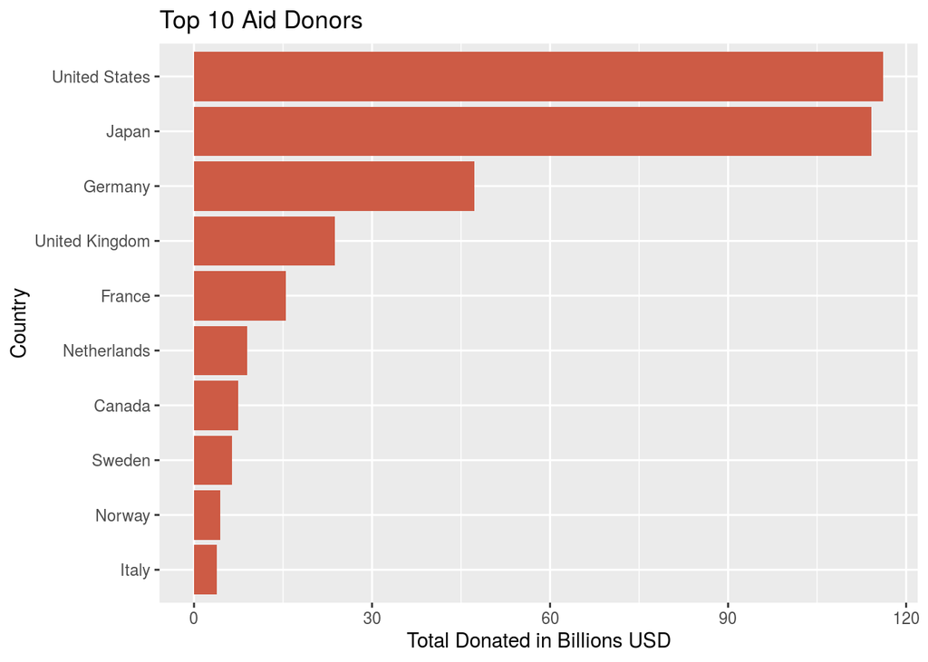

```r
aiddata_needed %>%
  select(-year, -recipient, -coalesced_purpose_code, -coalesced_purpose_name) %>%
  group_by(donor) %>%
  summarise( total_donated_billions = sum(commitment_amount_usd_constant) / 1000000000) %>%
  arrange(desc(total_donated_billions)) %>%
  slice(1:10)  %>%
  ggplot(aes(x=total_donated_billions, y=fct_reorder(donor,total_donated_billions))) +
  geom_col(fill = "coral3") +
  labs(title = "Top 10 Aid Donors", x = "Total Donated in Billions USD" , y = "Country")
```

Above are the top 10 Aid donors in the world. The United States and Japan lead in the amount of aid donations. When countries make aid donations, they also include a purpose for the donation. Below are the top ten donation purposes for all of the donations.

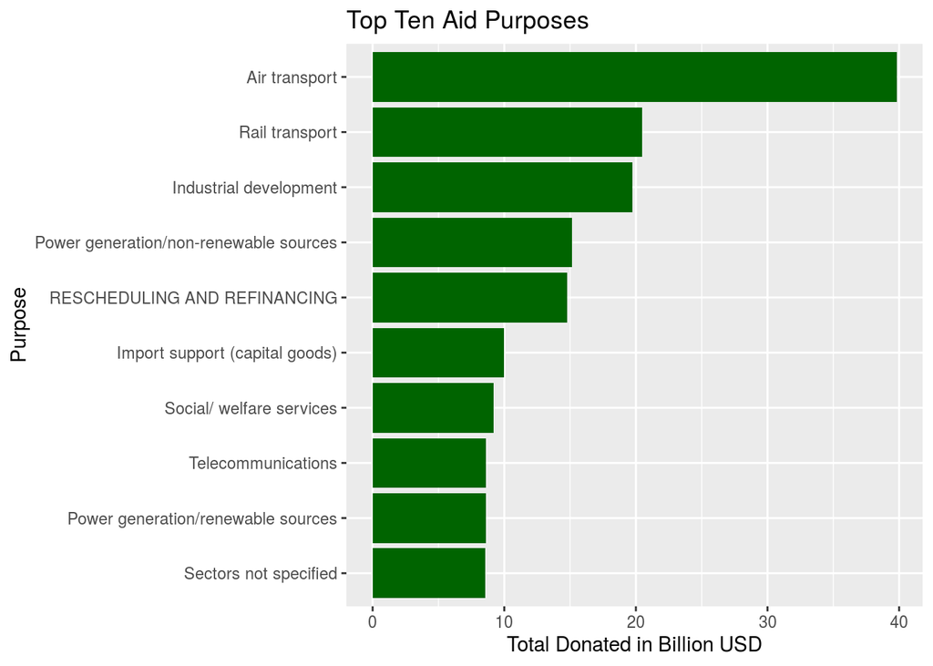

[figure not shown]

```r
aiddata_needed %>%
  select(-year, -donor, -recipient, -coalesced_purpose_code) %>%
  group_by(coalesced_purpose_name) %>%
  summarise(total_billions = sum(commitment_amount_usd_constant) / 1000000000) %>%
  arrange(desc(total_billions)) %>%
  slice(1:10) %>%
  ggplot(aes(x = total_billions, y = fct_reorder(coalesced_purpose_name,total_billions)))  +
  geom_col(fill = "darkgreen") +
  labs(title = "Top Ten Aid Purposes", x = "Total Donated in Billion USD", y = "Purpose" )
```

While the United States is one of the largest donors, that doesn’t mean that they have the most donations or contributions to each purpose. Note below that Germany has made the most contributions towards renewable energy.

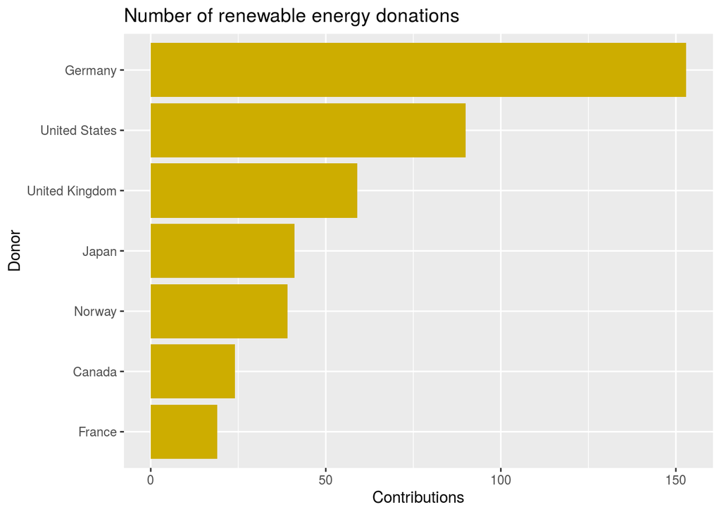

```r
aiddata %>%
  filter(coalesced_purpose_code == "23030") %>%
  group_by(donor) %>%
  summarize(total_contributions = n()) %>%
  ungroup() %>%
arrange(desc(total_contributions)) %>%
  slice(1:7) %>%
  ggplot(mapping = aes(x = fct_reorder(donor, total_contributions ), y = total_contributions)) +
    geom_col(fill = "gold3") +
    #theme(axis.text.x = element_text(angle = 30, hjust = 1)) +
    labs(title = "Number of renewable energy donations", y = "Contributions", x = "Donor") +
    coord_flip()
```

We can contrast this with the total amount in USD that countries contributed to see that Japan contributed more, despite the fact that Germany made significantly more contributions. In addition, the UK and the US made lots of contributions but the contributions had a low value.

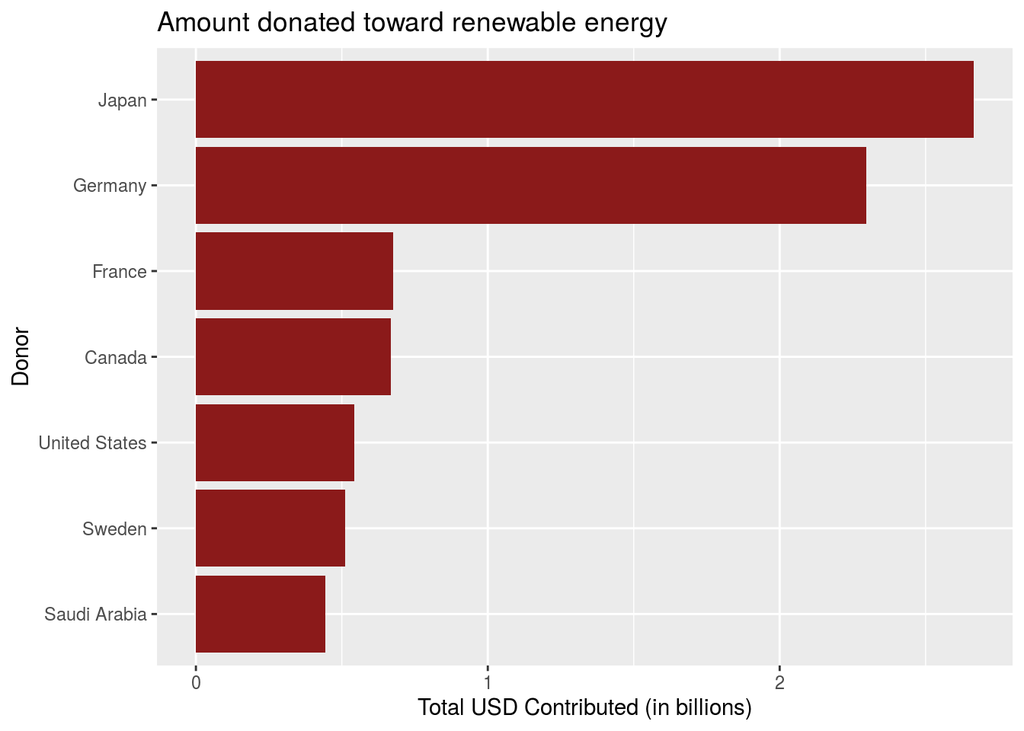

```r
aiddata %>%
  filter(coalesced_purpose_code == "23030") %>%
  group_by(donor) %>%
  summarize(total = sum(commitment_amount_usd_constant)) %>%
  ungroup() %>%
  arrange(desc(total)) %>%
  slice(1:7) %>%
  ggplot(mapping = aes(x = fct_rev(fct_reorder(donor,desc(total))),y = total / 1000000000)) +
    geom_col(fill = "firebrick4") +
    #theme(axis.text.x = element_text(angle = 30, hjust = 1)) +
    labs(title = "Amount donated toward renewable energy", y = "Total USD Contributed (in billions)", x = "Donor") +
    coord_flip()
```

Below, we can also see how the donations from the United States (for some of the top ten US purposes) have changed over time. You may notice that the top US Purpose, Air Transport, is no longer a top purpose in 2010.

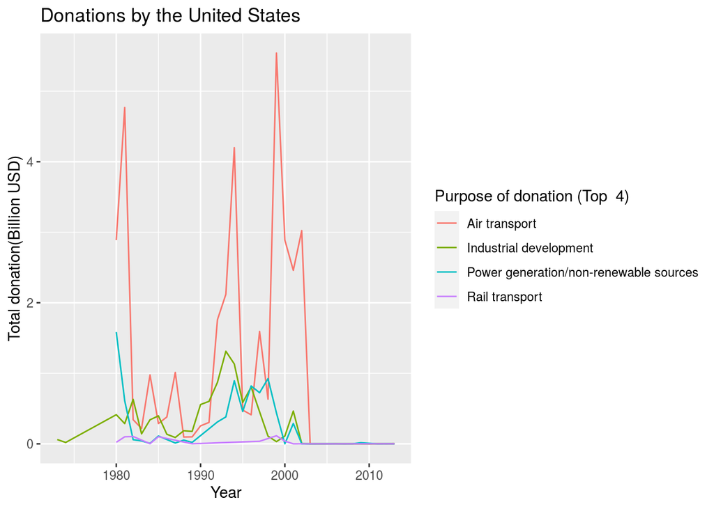

```r
aiddata %>%
  filter(donor == "United States",
    coalesced_purpose_name %in% c("Air transport",
                              "Rail transport",
                              "Industrial development",
                              "Power generation/non-renewable sources",
                              "RESCHEDULING AND REFINANCING")) %>%
  group_by(coalesced_purpose_name,year) %>%
  summarize(total_per_cause_per_year = sum(commitment_amount_usd_constant)) %>%
  arrange(desc(total_per_cause_per_year)) %>%
  ggplot() +
    geom_line(aes(x=year,y=total_per_cause_per_year/1000000000,
                  color=coalesced_purpose_name)) +
    labs(x = "Year",y="Total donation(Billion USD)",
                  title="Donations by the United States",
                  colour="Purpose of donation (Top  4)")
```

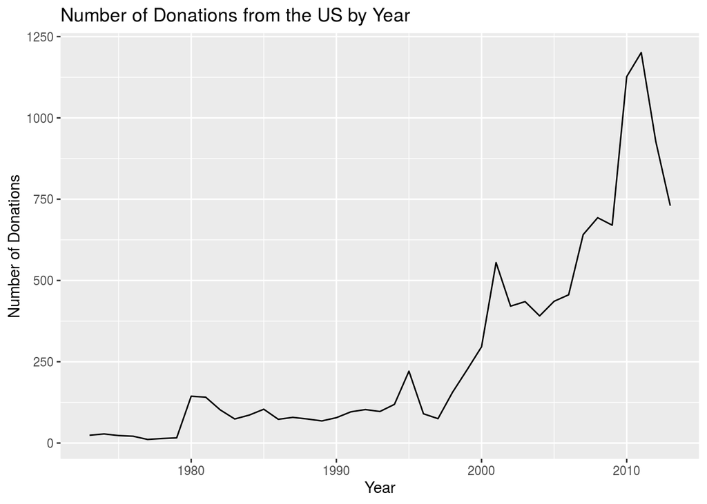

```r
aiddata %>%
  filter(donor == "United States") %>%
  group_by(year)  %>%
  summarise(total = n()) %>%
  ggplot() +
    geom_line(mapping = aes(x=year, y=total)) +
    labs(title = "Number of Donations from the US by Year", x = "Year", y = "Number of Donations")
```